# What’s the score?

Class

Author

Joshua Loftus

## How this sheet works

Exercises rederive or apply the lecture’s results. Do them on your own time; they are not worked in class. The class works the discussions, the problems and the simulation under “In class,” in that order. Discussions are in groups of three or four, then with the room. Each problem, and the simulation, is gone through as soon as the room has tried it.

## Exercises

Attempt each part before you open a hint.

**WarningHints**

Do not open a hint unless you have been stuck for at least a few minutes, and open them in order.

### Exercise 1. An offset and who is selected

The lecture’s model: need $Y^\star \sim N(0, 1)$ in both groups, $A = 1$ for one group and $A = 0$ for the other, the measure $Y = Y^\star + \beta_A A$, and a person is selected if $Y > t$. Now $t$ is group 0’s 90th percentile, $t = 1.28$, and $\beta_A = -0.5$. Use $\Phi(1.28) = 0.900$, $\Phi(1.78) = 0.9625$, $\phi(1.28) = 0.1758$ and $\phi(1.78) = 0.0818$, where $\Phi$ is the standard normal distribution function and $\phi$ its density.

1. What share of each group is selected? What is the ratio of the two shares?
2. What is the mean need of the selected in each group?
3. Two people, one from each group, have the same score $y$. How much more need does the person from group 1 have?
4. Which group’s selected members are sicker? Say why in one sentence.

**TipHint 1**

For group 1, $Y > t$ is the same event as $Y^\star > t - \beta_A$.

**TipHint 2**

The mean of a standard normal above $z$ is $\phi(z)/(1 - \Phi(z))$.

**NoteSolution**

1. Group 0: $P(Y^\star > 1.28) = 0.10$. Group 1: $P(Y^\star > 1.28 + 0.5) = 1 - 0.9625 = 0.0375$. The ratio is $0.0375/0.10 = 0.375$: an offset of half a standard deviation cuts group 1’s chance of selection to under two fifths of group 0’s.
2. Group 0: $0.1758/0.10 = 1.76$. Group 1: $0.0818/0.0375 = 2.18$.
3. $Y^\star = Y - \beta_A A$, so the person from group 0 has need $y$ and the person from group 1 has need $y + 0.5$: half a standard deviation more, whatever $y$ is. This is the comparison of the paper’s Figure 1A, where at the same score Black patients had more active chronic conditions (Obermeyer and colleagues 2019).
4. Group 1’s: its threshold on need is $t - \beta_A = 1.78$, not $1.28$, so only its sicker members clear it.

### Exercise 2. Noise and an omitted variable

From the lecture: health next year $Y$, doctor visits $X^\star$, reported as $X = X^\star + \varepsilon$, and illness $Z$, which is not in the data, with
$$Y = \beta X^\star + \gamma Z + U ,$$
where $U$ is everything else that affects health, and $\varepsilon$ and $U$ have mean zero and are independent of each other and of $X^\star$ and $Z$. Here $Y$ is health, not the measure of need of exercise 1 and problem 1.

1. Show that the slope of $X^\star$ on $X$ is $\lambda = \operatorname{Var}(X^\star)/\operatorname{Var}(X)$. (The lecture’s best guess of need from cost is the same calculation.)
2. Show that the slope of $Y$ on $X$ is $\lambda(\beta + \gamma\delta)$, where $\delta = \operatorname{Cov}(X^\star, Z)/\operatorname{Var}(X^\star)$.
3. Take $\beta = 1$ and $\lambda = 0.9$. Compute the slope for $\gamma\delta = 0.5$, $-0.5$ and $-1.5$. In each case, is it too large, too small or of the wrong sign?
4. Can noise in the report, independent of everything else as here, change the sign of the slope? For which values of $\gamma\delta$ is the slope in (c) larger than $\beta$?
5. Which of $\lambda$, $\gamma$ and $\delta$ can you learn from data on $X$ and $Y$ alone? What would you need to collect?

**TipHint 1**

Write $\operatorname{Cov}(X, Y)$ term by term. Every covariance between $\varepsilon$ or $U$ and anything else is zero.

**TipHint 2**

For (d), $\lambda$ is a ratio of variances.

**NoteSolution**

1. $\operatorname{Cov}(X^\star, X) = \operatorname{Cov}(X^\star, X^\star + \varepsilon) = \operatorname{Var}(X^\star)$ and $\operatorname{Var}(X) = \operatorname{Var}(X^\star) + \operatorname{Var}(\varepsilon)$, so the slope is $\operatorname{Var}(X^\star)/\operatorname{Var}(X) = \lambda$.
2. $$\operatorname{Cov}(X, Y) = \operatorname{Cov}(X^\star + \varepsilon,\ \beta X^\star + \gamma Z + U)
   = \beta \operatorname{Var}(X^\star) + \gamma \operatorname{Cov}(X^\star, Z),$$
   since every term with $\varepsilon$ or $U$ is zero. Dividing by $\operatorname{Var}(X) = \operatorname{Var}(X^\star)/\lambda$ gives $\lambda\,[\beta + \gamma \operatorname{Cov}(X^\star, Z)/\operatorname{Var}(X^\star)] = \lambda(\beta + \gamma\delta)$.
3. $0.9 \times 1.5 = 1.35$, too large. $0.9 \times 0.5 = 0.45$, too small. $0.9 \times (-0.5) = -0.45$, the wrong sign: in these data the people who visit more are less healthy next year, and the regression says visits do harm.
4. No. $\lambda$ is positive, so the slope has the sign of $\beta + \gamma\delta$; noise of this kind, independent of everything else, shrinks it toward zero, wrong sign and all. (Noise related to the true value, to the outcome or to $Z$ could move it either way.) The slope is larger than $\beta$ when $0.9(1 + \gamma\delta) > 1$, that is, $\gamma\delta > 1/9$. In general, for $\beta > 0$, when $\gamma\delta > \beta(1 - \lambda)/\lambda$. At $\gamma\delta = 1/9$ the two biases cancel and the estimate is right for the wrong reason.
5. None of them. The reliability $\lambda$ needs a second report of the same visits with its own independent error, such as the clinic’s records: the covariance of two such reports is $\operatorname{Var}(X^\star)$. The term $\gamma\delta$ needs a measure of illness, or a design in which visits do not depend on illness, such as free visits offered at random. With only $X$ and $Y$, the slope could be too large, too small or of the wrong sign. The slope is read as the effect of a visit with illness held fixed, and nothing held it fixed.

### Exercise 3. A fixed number of places (harder)

In exercise 1, suppose instead that the program has places for 10% of all patients, that the two groups are the same size, and that one threshold $t$ applies to both.

1. Write the equation that $t$ solves. Is $t$ above or below 1.28?
2. Solve it in R with `uniroot`. What share of the places goes to group 1? With no offset it would be half.
3. Compute the mean need of the selected in each group.

**TipHint 1**

The share of all patients selected is the average of the two groups’ shares.

**NoteSolution**

1. $\tfrac{1}{2}\,[1 - \Phi(t)] + \tfrac{1}{2}\,[1 - \Phi(t - \beta_A)] = 0.10$ with $\beta_A = -0.5$. At $t = 1.28$ only $\tfrac{1}{2}(0.10 + 0.0375) = 0.069$ of patients are selected, so to fill the places the threshold must fall below 1.28.

```r
b <- -0.5
f <- function(t) 0.5 * (1 - pnorm(t)) + 0.5 * (1 - pnorm(t - b)) - 0.10
t <- uniroot(f, c(0, 3))$root
s0 <- 1 - pnorm(t); s1 <- 1 - pnorm(t - b)
round(c(t = t, share0 = s0, share1 = s1, group1_places = s1 / (s0 + s1),
        need0 = dnorm(t) / s0, need1 = dnorm(t - b) / s1), 3)
```

```
            t        share0        share1 group1_places         need0
        1.072         0.142         0.058         0.290         1.583
        need1
        2.000
```

2. $t = 1.07$. Group 0 has 14.2% selected and group 1 5.8%, so group 1 gets 29% of the places instead of half. With a fixed number of places, an offset that lowers one group’s scores moves places to the other group.
3. 1.58 in group 0 and 2.00 in group 1: the selected in group 1 are sicker by 0.42.

### Exercise 4. Gaming or improvement

1. From the lecture: learning the examiner’s favorite phrasing. Draw its graph. Is it gaming or improvement?
2. Choose a score and one way people respond to it. Draw the graph and say which it is.

**TipHint 1**

A response is improvement if it raises what the score stands for, and the score with it; gaming if it raises the score by a route that does not pass through what the score stands for.

**NoteSolution**

1. Phrasing $\to$ test score, beside skill $\to$ test score. If the test is meant to measure understanding of the subject, the arrow goes around skill and it is gaming. If writing in the expected form is part of the skill being taught, the arrow goes through skill and it is improvement. The graph depends on what the test is for.
2. For example: students who take more practice tests before a standardized test (practice $\to$ skill $\to$ score is improvement, practice $\to$ familiarity with the format $\to$ score is not), or borrowers who open a credit card to build a credit history.

### Exercise 5. Prediction letters and reinforcement-learning letters

The decision whether to prescribe hormone therapy to prevent heart disease can be written with the letters used for prediction or with those of reinforcement learning.

1. Write it with the letters used for prediction. Say what the treatment, the outcome and a confounder are, and write the quantity a doctor needs with $do(\cdot)$.
2. Write it with the letters of reinforcement learning, with the one-line declaration at the top. Say what the state, the action, the reward, the policy and the utility are.
3. Which letters would mean different things if you used them in both answers?

**TipHint 1**

For (a), what does the doctor choose, and what could affect both that choice and heart disease? For (b), what does the doctor know when choosing?

**NoteSolution**

1. $X = 1$ if the doctor prescribes hormone therapy, $Y = 1$ if the woman has coronary heart disease within five years, $Z$ her socioeconomic status. A doctor needs $P(Y = 1 \mid do(X := 1))$ against $P(Y = 1 \mid do(X := 0))$, not $P(Y = 1 \mid X = 1)$ against $P(Y = 1 \mid X = 0)$.
2. **Notation:** this answer uses the letters of reinforcement learning, $S$ state, $A$ action, $R$ reward, $\pi$ policy, $U$ utility. $S$ is the patient’s state: age, time since the menopause, risk factors. $A$ is prescribe or do not. $\pi$ is the prescribing rule from state to action. $R$ is a measured reward, such as no heart attack recorded in five years. $U$ is what we care about: her health, including breast cancer, stroke and fractures as well as the heart.
3. $A$, $R$ and $U$. With the letters used for prediction they are a group, a risk score and an unobserved variable.

### Exercise 6. Noise and an omitted variable, simulated

Exercise 2’s model as a program.

```r
n <- 100000
illness  <- rnorm(n)                                  # Z, not in the data
visits   <- illness + rnorm(n)                        # X*: the ill visit more
reported <- visits + rnorm(n, sd = 0.5)               # X, the number reported
health   <- 0.5 * visits - 1.5 * illness + rnorm(n)   # Y: beta = 0.5, gamma = -1.5
coef(lm(health ~ reported))
```

1. Compute $\lambda$, $\delta$ and the slope you expect from exercise 2. Then run it.
2. Make the reports noisier, `sd = 2`. What do you expect? Run it.
3. Fit `lm(health ~ reported + illness)`. Is the coefficient on `reported` now $\beta = 0.5$? Why or why not?

**TipHint 1**

$\operatorname{Var}(X^\star) = \operatorname{Var}(Z) + 1$ and $\operatorname{Cov}(X^\star, Z) = \operatorname{Var}(Z)$.

**NoteSolution**

```r
n <- 100000
illness  <- rnorm(n)
visits   <- illness + rnorm(n)
reported <- visits + rnorm(n, sd = 0.5)
health   <- 0.5 * visits - 1.5 * illness + rnorm(n)
noisier  <- visits + rnorm(n, sd = 2)
round(c(slope = coef(lm(health ~ reported))[[2]],
        noisier = coef(lm(health ~ noisier))[[2]],
        adjusted = coef(lm(health ~ reported + illness))[[2]]), 3)
```

```
   slope  noisier adjusted
  -0.221   -0.085    0.400
```

1. $\operatorname{Var}(X^\star) = 2$, so $\lambda = 2/2.25 = 0.89$; $\delta = 1/2$, so $\gamma\delta = -0.75$; the slope is $0.89 \times (0.5 - 0.75) = -0.22$. The fit gives about that.
2. $\lambda = 2/6 = 1/3$ and the slope is $-0.25/3 = -0.083$: closer to zero, still the wrong sign.
3. About 0.40, not 0.5. Adjusting for illness removes the confounding, but the noise remains, and it now matters more. The coefficient is the slope of health on the part of `reported` that illness does not predict, $(X^\star - Z) + \varepsilon$, whose reliability is $1/(1 + 0.25) = 0.8$, so the coefficient is $0.8 \times 0.5 = 0.40$. Adjusting for a variable related to the true value leaves less of the true value’s variation, and the noise is a larger share of what is left.

## In class

### Discussion 1: a score you know

If you brought a score or algorithm used to make decisions about people, use it. If not, choose one: a credit score, a tool that screens CVs, a map that tells police where to patrol, the ranking of a social media feed, a university league table, the $h$-index.

1. What does it measure, and what is it taken to stand for? Give one ethical consideration it raises.
2. A common answer to “why do algorithms treat groups unequally?” is “the training data were biased.” Think of the hospital’s risk score from the lecture. Were its cost data wrong? Where did the problem come from?

Every group’s examples go on the screen.

**NoteSome examples**

- A credit score measures how a person has repaid credit before and is taken to stand for whether they will repay a new loan. Someone who has never borrowed has little to measure.
- A CV-screening tool measures how much a CV resembles the CVs of past hires and is taken to stand for how well the applicant would do the job. It inherits whoever chose the past hires.
- A predictive-policing map measures recorded crime, which depends on where police already patrol, and is taken to stand for where crime happens.
- A feed’s ranking measures engagement and is taken to stand for what is worth a user’s time.
- The $h$-index measures citations and is taken to stand for a researcher’s contribution.

The hospital’s cost data were an accurate record of cost. The problem was what cost was used to stand for: at the same need, Black patients generated less cost, so a score trained to predict cost flagged fewer of them. “Biased data” is too vague to act on. The authors’ remedy changed what the score predicts, not the data: in experiments with the manufacturer, they replaced future cost by “an index variable that combined health prediction with cost prediction,” which reduced the excess of chronic conditions among Black patients at the same score by 84% (Obermeyer and colleagues 2019, p. 453).

### Problem 1. Need, resources and care-seeking

The hospital’s cost depends on more than need. Write a person’s cost as
$$Y = Y^\star + W + C + \varepsilon ,$$
with need $Y^\star$; resources $W$ (insurance that pays, income, transport, time off work, a doctor who records every diagnosis); care-seeking $C$, how readily a person goes to a doctor at a given level of need; and noise $\varepsilon$. The four are independent and normal with mean zero and variances $1$, $1/2$, $1/4$ and $1/4$. The program offers a place to everyone whose cost is in the top 3%: $D = 1$ if $Y > t$.

1. Draw the graph with $Y^\star$, $W$, $C$, $Y$ and $D$. Then sort $Y^\star$, $W$ and $C$ by how far each is under a person’s own control.
2. Show that $E[Y^\star \mid Y = y] = \dfrac{\operatorname{Var}(Y^\star)}{\operatorname{Var}(Y)}\, y$, and write the same for $W$ and $C$. What do these three fractions and the one for $\varepsilon$ add up to?
3. The mean of a standard normal above its 97th percentile is 2.27. Compute the mean cost of the people offered a place, and the mean of each part among them. What share of their mean cost, measured from the population mean of zero, comes from need? What share from the part most under their control?
4. Suppose poorer people are sicker: add an arrow from $W$ to $Y^\star$, with a negative effect, keeping the variance of need at 1. Without computing, does the mean need of the people offered a place go up or down? Why?
5. In the original model, $Y^\star$ and $W$ are independent. Among the people offered a place, would you expect need and resources to be related? In which direction?

**TipHint 1**

For (b), use exercise 2(a), with $Y$ in the place of exercise 2’s $X$ and $Y^\star$ in the place of $X^\star$: everything in $Y$ except $Y^\star$ plays the part of the noise. When the parts are normal, $E[Y^\star \mid Y = y]$ is that slope times $y$.

**TipHint 2**

For (c), $E[Y^\star \mid Y > t] = E\big[E[Y^\star \mid Y] \,\big|\, Y > t\big]$, and $Y$ is normal with standard deviation $\sqrt{2}$.

**NoteSolution**

1. $Y^\star \to Y$, $W \to Y$, $C \to Y$ and $Y \to D$. The noise $\varepsilon$ can be drawn with its own arrow into $Y$ or left out. The second panel is the graph of (d).

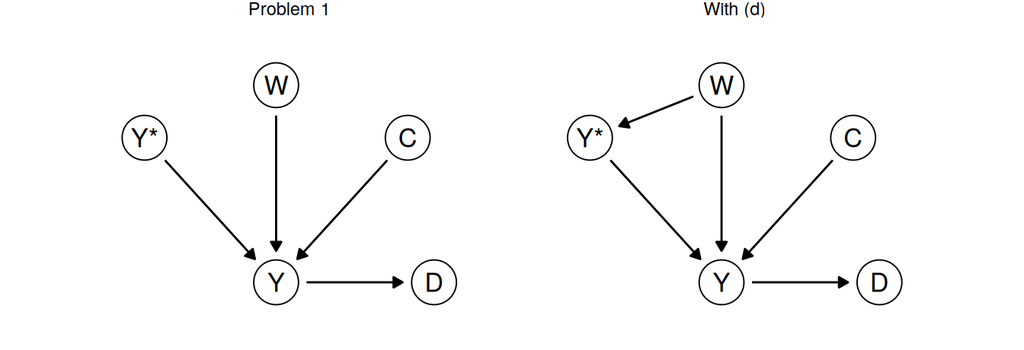

Care-seeking $C$ is the most under a person’s control: going to the doctor is partly a choice. Resources $W$ much less: income, insurance that comes with a job, where a person lives. Need $Y^\star$ least. The sort is itself a judgment. How readily someone seeks care depends on circumstances too (time off work, distance, how doctors have treated them before), and some illness follows from past choices.

2. The parts are independent, so $\operatorname{Cov}(Y^\star, Y) = \operatorname{Var}(Y^\star)$, and as in exercise 2(a) the slope of $Y^\star$ on $Y$ is $\operatorname{Var}(Y^\star)/\operatorname{Var}(Y)$. With everything normal, that slope is the conditional mean. In the same way $E[W \mid Y = y] = \dfrac{\operatorname{Var}(W)}{\operatorname{Var}(Y)}\, y$ and $E[C \mid Y = y] = \dfrac{\operatorname{Var}(C)}{\operatorname{Var}(Y)}\, y$. The four fractions add up to 1, because $\operatorname{Var}(Y)$ is the sum of the four variances.
3. $\operatorname{Var}(Y) = 2$, so the mean cost of those offered a place is $\sqrt{2} \times 2.27 = 3.21$. The shares are $1/2$, $1/4$, $1/8$ and $1/8$, so the means are 1.60 for need, 0.80 for resources, 0.40 for care-seeking and 0.40 for noise. Half of their mean cost above the population mean comes from need, and an eighth from care-seeking, the part most under their control. A quarter comes from resources. The people offered a place are a mixture: some are there mostly because they are ill, some because they could turn need into care, some because they seek care readily.
4. Down. The sickest now tend to have fewer resources, so their cost is lower than their need, and cost picks out need less well. With $Y^\star = -0.5\,W + V$ and $\operatorname{Var}(V) = 0.875$, so that need still has variance 1, $\operatorname{Var}(Y) = 1.5$ and $\operatorname{Cov}(Y^\star, Y) = 0.75$, and the mean need of those offered a place falls from 1.60 to $0.5 \times \sqrt{1.5} \times 2.27 = 1.39$. This is the lecture’s offset again, inside one group.
5. Yes, negatively. To clear the threshold with less need, a person needed more of something else, such as resources. Selecting on something that both affect makes them related among the selected, although they are independent in the population. The simulation shows it.

### Discussion 2: allocating the places

The people offered a place in problem 1 got there by different routes.

1. Should it matter to the program why a person cleared the threshold? Would you treat a place that came from resources differently from one that came from seeking care readily?
2. The lecture’s question was whether the program should go to the sickest or to those it would help most. Where do resources and care-seeking come in? Someone who seeks care readily may also be the most likely to use the program.
3. Last week’s closing question, for everyone this time: does consequentialism become more or less defensible once you have to write the causal model down?

**NoteSome lines of argument**

There is no house answer.

One view in political philosophy holds that inequalities that come from people’s choices can be fair and those that come from their circumstances are not. Elizabeth Anderson, who calls it “luck egalitarianism,” describes its central distinction as one between outcomes that result from a person’s voluntary choices and outcomes “that occur independent of her choice or of what she could have reasonably foreseen” (Anderson 1999, pp. 289 and 292). On that view, a score that gives places for having resources rewards good luck, and one that gives places for seeking care rewards a choice. Anderson argues against the view: it would leave without help people whose own negligent choices led to their need, which she calls “the problem of abandonment of negligent victims” (p. 296), and it “makes demeaning and intrusive judgments of people’s capacities to exercise responsibility” (p. 289). And choices such as how readily to see a doctor are themselves shaped by circumstances: time off work, distance, how doctors have treated someone before.

A program judged by its benefit needs people to use it, and care-seeking may predict that. Choosing by benefit can then move places toward people who already get care.

Writing the causal model down makes the consequentialist’s claims explicit and open to criticism. Here the model needs the effect of the program for each kind of patient, and, if control matters, what each person could have done otherwise. Seeing how much rests on those assumptions is also an argument against relying on them.

### Simulation: selection on cost

One laptop between two. The model of problem 1, for 100,000 people.

```r
n <- 100000
need      <- rnorm(n)                     # Y*
resources <- rnorm(n, sd = sqrt(0.5))     # W
seeking   <- rnorm(n, sd = 0.5)           # C
noise     <- rnorm(n, sd = 0.5)
cost      <- need + resources + seeking + noise
selected  <- cost > quantile(cost, 0.97)  # the top 3% by cost are offered a place
parts <- data.frame(cost, need, resources, seeking, noise)
colMeans(parts[selected, ])
```

1. Run it, and compare the means with your answers to problem 1(c).
2. What share of the people offered a place are in the top 3% by need? `mean(need[selected] > quantile(need, 0.97))`
3. Plot need against resources for the people offered a place. What do you see? Compare it with your answer to problem 1(e).
4. Some people can raise their cost without being more ill: a doctor who records every diagnosis, knowing which tests to ask for. Say everyone with resources above the median adds 1 to their cost. Before you run anything, write down who you expect to gain places. Then change `cost`, run steps 1 and 2 again, and compare.
5. At home: make poorer people sicker, `need <- -0.5 * resources + rnorm(n, sd = sqrt(0.875))` (need still has variance 1), and run it again. Compare with problem 1(d).

**TipHint 1**

For step 4, add `(resources > median(resources))` to `cost`, then compute `selected` again.

**NoteSolution**

```r
n <- 100000
need      <- rnorm(n)
resources <- rnorm(n, sd = sqrt(0.5))
seeking   <- rnorm(n, sd = 0.5)
noise     <- rnorm(n, sd = 0.5)
cost      <- need + resources + seeking + noise
selected  <- cost > quantile(cost, 0.97)
parts <- data.frame(cost, need, resources, seeking, noise)
round(colMeans(parts[selected, ]), 2)                  # step 1
```

```
     cost      need resources   seeking     noise
     3.20      1.61      0.80      0.39      0.40
```

```r
mean(need[selected] > quantile(need, 0.97))            # step 2
```

```
[1] 0.358
```

```r
cor(need[selected], resources[selected])               # step 3
```

```
[1] -0.4428374
```

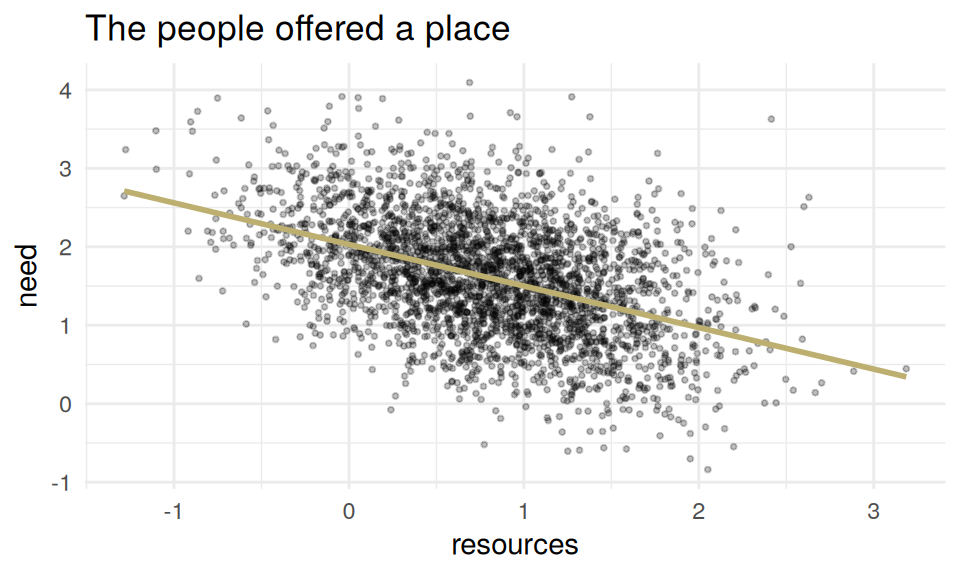

```r
ggplot(parts[selected, ], aes(resources, need)) +
  geom_point(alpha = 0.25, size = 0.7) +
  geom_smooth(method = "lm", se = FALSE, color = "#BCAF6F") +
  labs(x = "resources", y = "need", title = "The people offered a place")
```

```r
cost_g <- cost + (resources > median(resources))       # step 4
selected_g <- cost_g > quantile(cost_g, 0.97)
round(colMeans(data.frame(cost = cost_g, need, resources, seeking, noise)[selected_g, ]), 2)
```

```
     cost      need resources   seeking     noise
     4.16      1.52      0.90      0.37      0.38
```

```r
mean(need[selected_g] > quantile(need, 0.97))
```

```
[1] 0.3076667
```

```r
c(before = mean(resources[selected] > median(resources)),
  after = mean(resources[selected_g] > median(resources)))
```

```
   before     after
0.8980000 0.9923333
```

```r
need2 <- -0.5 * resources + rnorm(n, sd = sqrt(0.875))  # step 5
cost2 <- need2 + resources + seeking + noise
round(mean(need2[cost2 > quantile(cost2, 0.97)]), 2)
```

```
[1] 1.37
```

1. About 3.21, 1.60, 0.80, 0.40 and 0.40, the answers to problem 1(c). Each run differs by a few hundredths.
2. About 0.35. About a third of the places go to people in the top 3% by need. The rest go to people with less need than others who were not offered a place.
3. A cloud that slopes down, with a correlation of about $-0.45$ ($-0.47$ in a very large sample). In the population the two are independent. Among the people offered a place, those with less need have more resources: they cleared the threshold another way.
4. People with resources above the median gain places: they were about 90% of those offered a place, and now are about 99%. The mean need of those offered a place falls from 1.60 to about 1.51, and the share in the top 3% by need from about 0.35 to about 0.30. The gain went to the people who could respond, as in the lecture’s simulation, and here the ability to respond is a resource.
5. About 1.39, the answer to problem 1(d).

### Problem 2. Changing the label

The paper’s authors measured health by the number of active chronic conditions, counted from the diagnoses in patients’ electronic health records (Obermeyer and colleagues 2019, p. 448), and trained a model to predict that count instead of cost (p. 451). Suppose the hospital offers its places by predicted active chronic conditions instead of predicted cost.

1. A condition is recorded only when a doctor sees the patient. Draw the graph with need $Y^\star$, resources $W$, care-seeking $C$, contact with doctors and the recorded count. Which of problem 1’s arrows into cost reach the count, and by what route?
2. A doctor who records every diagnosis raises a patient’s count. Is that gaming or improvement? What does the answer depend on?
3. Suppose payments come to depend on the count. What would you expect to happen to the count, and to what it says about need?
4. In experiments with the manufacturer, the authors replaced future cost by “an index variable that combined health prediction with cost prediction” (p. 453). Which lens asks about that choice? What is still chosen by someone?

**TipHint 1**

For (a), what has to happen before a condition appears in a record?

**TipHint 2**

For (b), use the lecture’s definitions: a response is improvement if it raises what the measure stands for, and the measure with it; gaming if it raises the measure by a route that does not pass through what it stands for.

**NoteSolution**

1. Need $\to$ contact with doctors $\to$ count, and need $\to$ count directly (a condition has to exist to be recorded); resources $W$ and care-seeking $C$ $\to$ contact with doctors. The arrows from $W$ and $C$ still reach the label, through contact with doctors rather than through spending. The paper’s Table 2 shows the label mattered: among the patients each model ranks highest, the Black share is 14.1% for the model that predicts total cost and 26.7% for the model that predicts active chronic conditions (Obermeyer and colleagues 2019, p. 452). That the share rose does not show that the gap in contact with care stopped mattering.
2. It depends on whether the recorded conditions are real. If they were there and had been missed, the record moves closer to need: a better measurement, though the patient is no sicker. If they are not, the count rises by a route that does not pass through need, which is gaming with need as what the count stands for. A record cannot show which, without an independent check of the patient.
3. Once payments depend on the count, there is a reason to record more diagnoses, and the count comes to measure coding as well as need: the lecture’s intervention on the equation for the measure. This has been measured in Medicare. Enrollees in private Medicare plans, whose payments depend on the diagnoses they report, have diagnosis-based risk scores 6% to 16% higher than they would have in traditional Medicare, “where diagnoses do not affect most provider payments” (Geruso and Layton 2020, abstract). Who can code more intensively (insurers and practices with the staff to do it) is a resource, so the count can pick up $W$ again by another route.
4. What are we optimizing or predicting? The index still needs a weight on health against cost, a measure of health (here, recorded diagnoses again) and a threshold, and someone chooses each.

### Discussion 3: a visa streaming tool

The Home Office used a “streaming tool” that rated each visa application red, amber or green. A red rating meant more scrutiny, and red applications were much less likely to succeed. Applications from nationalities on a “suspect” list were rated red automatically, and a nationality could be put on the list for a high number of “adverse events,” which included having visa applications refused (Jennings 2020). After the Joint Council for the Welfare of Immigrants and Foxglove brought a legal challenge, the Home Office said in August 2020 that it would stop using the tool, pending a redesign (Jennings 2020; Foxglove 2020).

1. Draw the loop from a rating to the list and back.
2. Is this strategic classification, performative prediction or neither?
3. Who bears the error?

**NoteSome lines of argument**

Rating red $\to$ more refusals $\to$ more “adverse events” for that nationality $\to$ the nationality stays on the list $\to$ rated red. Jennings (2020) calls it a risk of “a vicious cycle where certain nationalities would be locked onto the EANRA ‘suspect’ list.”

The applicants did not change their applications to get a better rating, so this is not strategic classification in the lecture’s sense. The ratings changed the data that later decided the ratings: the predictions changed the distribution they were judged on, which is the setting of performative prediction, here through the decisions of the system itself rather than through the people scored.

The error falls on applicants from the listed nationalities: the more scrutiny an application gets, the more chances to refuse it, whatever the applicant’s own circumstances.

## If there is time

- For the score from discussion 1, draw the graph of one way people respond to it. Is it gaming or improvement?
- The score from discussion 1: which of the things it responds to are under the control of the people scored?

## For next time

Bring one dataset or study where some people who should be in it are not. Write down who is missing, and in which direction their absence pushes the result. Every group’s examples will go on the screen.

## References

- Anderson, Elizabeth S., “What Is the Point of Equality?” (*Ethics* 109(2), 1999, 287–337), https://doi.org/10.1086/233897.
- Foxglove, “Home Office says it will abandon its racist visa algorithm – after we sued them” (4 August 2020), https://www.foxglove.org.uk/news/home-office-says-it-will-abandon-its-racist-visa-algorithm-nbsp-after-we-sued-them.
- Geruso, Michael and Timothy Layton, “Upcoding: Evidence from Medicare on Squishy Risk Adjustment” (*Journal of Political Economy* 128(3), 2020, 984–1026), https://doi.org/10.1086/704756.
- Jennings, Rafe, “Government Scraps Immigration ‘Streaming Tool’ before Judicial Review” (*UK Human Rights Blog*, 6 August 2020), https://ukhumanrightsblog.com/2020/08/06/government-scraps-immigration-streaming-tool-before-judicial-review/.
- Obermeyer, Ziad, Brian Powers, Christine Vogeli and Sendhil Mullainathan, “Dissecting racial bias in an algorithm used to manage the health of populations” (*Science* 366(6464), 2019, 447–453), https://doi.org/10.1126/science.aax2342.